# **Functional Programming**

andrés castro araújo

Dec 31, 2019

> All of this is taken from Hadley Wickham’s [**Advanced R**](https://adv-r.hadley.nz). CRC Press, 2019.

## Introduction

R lends itself to a *functional style* of programming.

> Functional languages have **first-class functions**, functions that behave *like any other data structure.* In R, this means that you can do many of the things with a function that you can do with a vector: you can assign them to variables, store them in lists, pass them as arguments to other functions, create them inside functions, and even return them as the result of a function.

Many functional languages require that functions are **pure** (i.e. that every input results in the same outputs). This is obviously not the case in R (e.g. `runif()`, `read.csv()`). So even though R isn’t strictly speaking a functional language, it certainly resembles one.

> It’s hard to describe exactly what a functional *style* is, but generally I think it means decomposing a big problem into smaller pieces, then solving each piece with a function or combination of functions. When using a functional style, you strive to decompose components of the problem into isolated functions that operate independently. Each function taken by itself is simple and straightforward to understand; complexity is handled by composing functions in various ways.

This notebook in particular is about **higher-order functions**. These functions can be categorized depending on their inputs and outputs, in accordance with this handy two-by-two table:

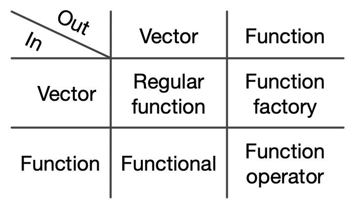

## Functionals

> A **functional** is a function that takes a function as an input and returns a vector as output. Here’s a simple functional: it calls the function provided as input with 100 random uniform numbers.

```r
randomize <- function(f) f(runif(100))
randomize(mean)
```

```
[1] 0.4703325
```

```r
randomize(sum)
```

```
[1] 48.88931
```

> The chances are that you’ve already used a functional. You might have used for-loop replacements like base R’s `lapply()`, `apply()`, and `tapply()`; or purrr’s `map()`; or maybe you’ve used a mathematical functional like `integrate()` or `optim()`.

```r
integrate(dnorm, lower = 0, upper = Inf)
```

```
0.5 with absolute error < 4.7e-05
```

### Map

```r
library(tidyverse)
```

The most important functional is *`purrr::map()`* (equivalent to `base::lapply()`): it takes a vector and a function, calls the function once for each element of the vector, and returns the results in a list.

```r
map(1:3, function(x) x^2)  ## using anonymous or lambda function
```

```
[[1]]
[1] 1

[[2]]
[1] 4

[[3]]
[1] 9
```

The name “map” comes from mathematics, where “an operation that associates each element of a given set with one or more elements of a second set”.

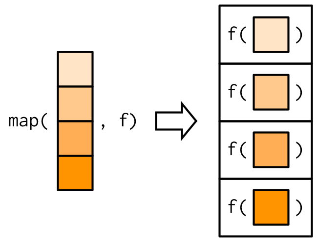

The inner workings of `map()` are pretty much what we can expect from a for loop:

```r
output <- vector("list", length(x))
for (i in seq_along(x)) {
  output[[i]] <- f(x[[i]])
}
```

There are many variants to `map()` that can be identified via conventional suffixes like `_dbl` to specify the type of *atomic vector* we want to receive as output.

```r
map_chr(mtcars, is.numeric)  ## remember that data frames are lists of lists.
```

```
   mpg    cyl   disp     hp   drat     wt   qsec     vs     am   gear
"TRUE" "TRUE" "TRUE" "TRUE" "TRUE" "TRUE" "TRUE" "TRUE" "TRUE" "TRUE"
  carb
"TRUE"
```

```r
map_dbl(mtcars, max) %>%
  map_dbl(round, digits = 1) ## using dot-dot-dot
```

```
  mpg   cyl  disp    hp  drat    wt  qsec    vs    am  gear  carb
 33.9   8.0 472.0 335.0   4.9   5.4  22.9   1.0   1.0   5.0   8.0
```

The `map()` family is different from `lapply()` (and other `base` variants) because it supports some shortcuts.

For example, the “twiddle” syntax (~):

```r
identical(
  map_dbl(mtcars, ~ length(unique(..1))),          ## twiddle syntax
  map_dbl(mtcars, function(x) length(unique(x)))   ## alternative
  )
```

```
[1] TRUE
```

```r
map(1:3, ~ rnorm(10)) %>% str()                         ## twiddle syntax
```

```
List of 3
 $ : num [1:10] -0.235 -0.854 0.943 -1.399 -0.206 ...
 $ : num [1:10] 0.425 -0.746 0.118 -0.919 1.852 ...
 $ : num [1:10] 1.148 0.588 1.649 0.561 -0.479 ...
```

```r
map(1:3, function(x) rnorm(10)) %>% str()               ## alternative
```

```
List of 3
 $ : num [1:10] 0.406 -1.126 0.812 0.654 -0.918 ...
 $ : num [1:10] -0.0993 1.3218 1.0768 -0.3302 0.7412 ...
 $ : num [1:10] -0.335 0.456 0.321 0.181 0.788 ...
```

```r
replicate(n = 3, rnorm(10), simplify = FALSE) %>% str() ## other alternative
```

```
List of 3
 $ : num [1:10] -1.0459 0.90161 -2.16193 -2.15239 -0.00508 ...
 $ : num [1:10] -0.709 -0.115 -0.998 0.651 0.274 ...
 $ : num [1:10] -0.353 -0.109 1.344 0.479 0.783 ...
```

*Varying a different argument*

> So far the first argument to `map()` has always become the first argument to the function. But what happens if the first argument should be constant, and you want to vary a different argument? How do you get the result in this picture?

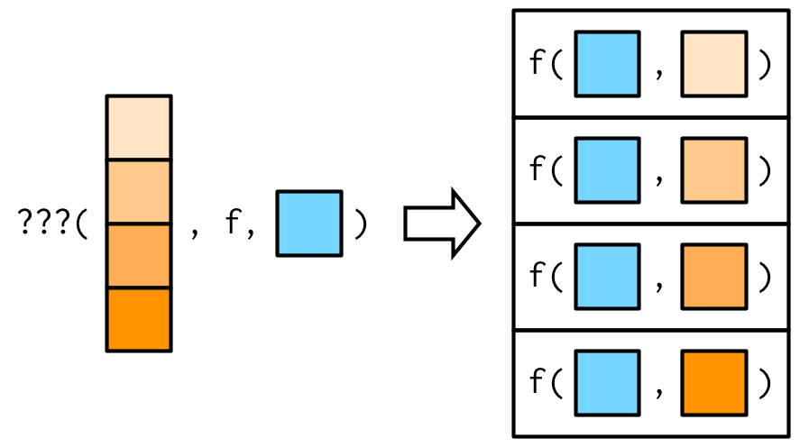

```r
draws <- rcauchy(1000)
trims <- c(0, 0.1, 0.2, 0.5)

map_dbl(trims, ~ mean(draws, trim = ..1))
```

```
[1] -0.84381601  0.06334065  0.02670249  0.03276163
```

```r
map_dbl(trims, function(input) mean(x = draws, trim = input))
```

```
[1] -0.84381601  0.06334065  0.02670249  0.03276163
```

```r
map_dbl(trims, mean, x = draws) ## using R's flexible argument matching
```

```
[1] -0.84381601  0.06334065  0.02670249  0.03276163
```

**Piping multiple `purrr` functions**

```r
base::split(mtcars, mtcars$cyl) %>% ## split data frame into three, by cyl
  map(function(df) lm(mpg ~ wt, data = df)) %>% ## fit linear model three times
  map(coefficients) %>% ## access coefficients
  map_dbl(pluck, "wt")  ## extract slope
```

```
        4         6         8
-5.647025 -2.780106 -2.192438
```

```r
## Loop alternative
slopes <- vector("double", 3)
for (i in seq_along(slopes)) {
  model <- lm(mpg ~ wt, data = base::split(mtcars, mtcars$cyl)[[i]])
  slopes[[i]] <- coef(model)[["wt"]]
}
slopes
```

```
[1] -5.647025 -2.780106 -2.192438
```

*Exercises.*

> `map(1:3, ~ runif(2))` is a useful pattern for generating random numbers, but `map(1:3, runif(2))` is not. Why not? Can you explain why it returns the result that it does?

`map()` uses `as_mapper()` to turn it’s second argument into a function that then gets applied to each element in the first argument.

In the first case, the twiddle syntax succesfully turns `~ runif(2)` into an anonymous function that then gets applied one time for every iteration.

In the second case, `as_mapper()` fails to turn `runif(2)` into a function. If the second argument is a *character vector*, *numeric vector*, or *list*, then `as_mapper()` turns this into an extractor function that uses `purr::pluck()` to extract elements.

```r
as_mapper(~runif(2))
```

```
<lambda>
function (..., .x = ..1, .y = ..2, . = ..1)
runif(2)
attr(,"class")
[1] "rlang_lambda_function" "function"
```

```r
as_mapper(runif(2))
```

```
function (x, ...)
pluck(x, 0.694184349151328, 0.599551955703646, .default = NULL)
<environment: 0x7f8ffaf98f28>
```

This is how it works:

```r
identical(map(1:3, 1), map(1:3, pluck, 1))
```

```
[1] TRUE
```

> Use the appropriate `map()` function to:

```r
# 1. Compute the standard deviation of every column in a numeric data frame.
map_dbl(mtcars, sd)
```

```
        mpg         cyl        disp          hp        drat          wt
  6.0269481   1.7859216 123.9386938  68.5628685   0.5346787   0.9784574
       qsec          vs          am        gear        carb
  1.7869432   0.5040161   0.4989909   0.7378041   1.6152000
```

```r
# 2. Compute the standard deviation of every numeric column in a mixed data frame.
index <- map_lgl(iris, is.numeric)
map_dbl(iris[index], sd)
```

```
Sepal.Length  Sepal.Width Petal.Length  Petal.Width
   0.8280661    0.4358663    1.7652982    0.7622377
```

```r
# Compute the number of levels for every factor in a data frame.
map(iris[!index], attr, which = "levels")
```

```
$Species
[1] "setosa"     "versicolor" "virginica"
```

> The following code simulates the performance of a t-test for non-normal data. Extract the p-value from each test, then visualise.

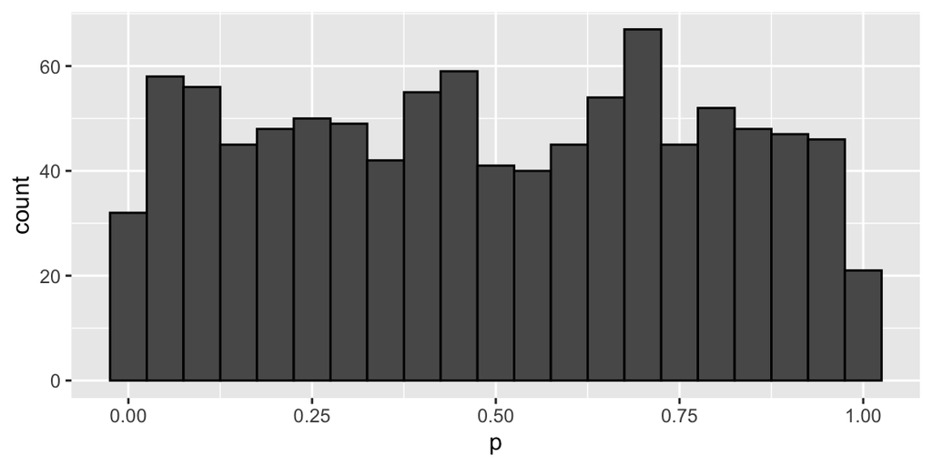

```r
trials <- map(1:1000, ~ t.test(rpois(10, 10), rpois(7, 10)))

tibble(p = map_dbl(trials, "p.value")) %>%
  ggplot(aes(p)) + geom_histogram(binwidth = 0.05, color = "black")
```

> Use map() to fit linear models to the mtcars dataset using the formulas stored in this list:

```r
formulas <- list(
  mpg ~ disp,
  mpg ~ I(1 / disp),
  mpg ~ disp + wt,
  mpg ~ I(1 / disp) + wt
)

formulas %>%
  map(~ lm(..1, data = mtcars)) %>%
  map(coefficients)
```

```
[[1]]
(Intercept)        disp
29.59985476 -0.04121512

[[2]]
(Intercept)   I(1/disp)
   10.75202  1557.67393

[[3]]
(Intercept)        disp          wt
34.96055404 -0.01772474 -3.35082533

[[4]]
(Intercept)   I(1/disp)          wt
  19.024206 1142.559975   -1.797649
```

> Fit the model `mpg ~ disp` to each of the bootstrap replicates of mtcars in the list below, then extract the $R^2$ of the model fit.

```r
bootstrap <- function(df) {
  df[sample(nrow(df), replace = TRUE), , drop = FALSE]
}

bootstraps <- map(1:10, ~ bootstrap(mtcars))

bootstraps %>%
  map(function(df) lm(mpg ~ disp, data = df)) %>%
  map(summary) %>%
  map_dbl("r.squared") ## extractor
```

```
 [1] 0.7326523 0.8177673 0.8147994 0.6613001 0.7617651 0.7941848 0.7588190
 [8] 0.7154688 0.7307951 0.6536009
```

### Varieties of Map

- Output same type as input with `modify()`
- Iterate over two inputs with `map2()`
- Iterate with an index using `imap()`
- Return nothing with `walk()`
- Iterate over any number of inputs with `pmap()`

|  | List | Atomic | Same Type | Nothing |
| --- | --- | --- | --- | --- |
| One argument | `map()` | `map_lgl(), ...` | `modify()` | `walk()` |
| Two arguments | `map2()` | `map2_lgl(), ...` | `modify2()` | `walk2()` |
| One argument + index | `imap()` | `imap_lgl(), ...` | `imodify()` | `iwalk()` |
| N arguments | `pmap()` | `pmap_lgl(), ...` |  | `pwalk()` |

**Same type of output as input: `modify()`**

```r
df <- data.frame(
  x = 1:3,
  y = 6:4
)

map(df, scale) %>% str()  ## returns a list
```

```
List of 2
 $ x: num [1:3, 1] -1 0 1
  ..- attr(*, "scaled:center")= num 2
  ..- attr(*, "scaled:scale")= num 1
 $ y: num [1:3, 1] 1 0 -1
  ..- attr(*, "scaled:center")= num 5
  ..- attr(*, "scaled:scale")= num 1
```

```r
modify(df, scale)         ## returns a data.frame
```

```
   x  y
1 -1  1
2  0  0
3  1 -1
```

**Two inputs: `map2()` and friends**

```r
## Example: finding a weighted mean
x <- map(1:5, ~ rnorm(20))
wt <- map(1:5, ~ runif(20))

weighted.mean(x[[1]], wt[[1]]) ## first element of each list
```

```
[1] -0.266978
```

```r
## Passing wt as an additional argument doesn’t work because arguments
## after .f are not transformed:
map(x, weighted.mean, w = wt)
```

```
Error in weighted.mean.default(.x[[i]], ...): 'x' and 'w' must have the same length
```

For this we use the `map2()` variety, which is vectorised over two arguments. This means both `..1` and `..2` are varied in each call to `weighted.mean`

```r
x[[3]][[3]] <- NA
map2_dbl(x, wt, weighted.mean)
```

```
[1] -0.2669780  0.1703410         NA -0.1999874 -0.8086110
```

[output not shown]

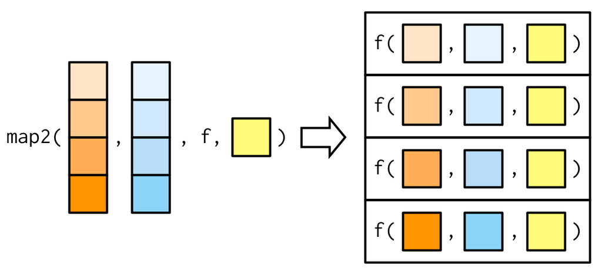

```r
map2_dbl(x, wt, weighted.mean, na.rm = TRUE)
```

**No outputs: `walk()` and friends**

> Some functions are called primarily for their side-effects (e.g. `cat()`, `write.csv()`, or `ggsave()`) and it doesn’t make sense to capture their results.

```r
eat_fruit <- function(x) {
  cat("Eat some more ", x, "!\n", sep = "")
}

sample(fruit, size = 5) %>%
  map(eat_fruit)
```

[output not shown]

To prevent `NULL` from showing up, we use `walk()`, which returns the input values through `invisible()`.

```r
sample(fruit, size = 5) %>%
  walk(eat_fruit)
```

```
Eat some more kumquat!
Eat some more avocado!
Eat some more cherry!
Eat some more date!
Eat some more guava!
```

```r
walk(1:5, ~ rnorm(10))
```

A very common use case for this pattern is saving some object to disk.

```r
temp <- tempfile()
dir.create(temp)

species <- split(iris, iris$Species)  ## list of three
paths <- file.path(temp, paste0("species-", names(species), ".rds"))
walk2(species, paths, write_rds)

list.files(temp)
```

```
[1] "species-setosa.rds"     "species-versicolor.rds"
[3] "species-virginica.rds"
```

```r
read_rds(paste0(temp, "/species-setosa.rds")) %>% head()
```

```
  Sepal.Length Sepal.Width Petal.Length Petal.Width Species
1          5.1         3.5          1.4         0.2  setosa
2          4.9         3.0          1.4         0.2  setosa
3          4.7         3.2          1.3         0.2  setosa
4          4.6         3.1          1.5         0.2  setosa
5          5.0         3.6          1.4         0.2  setosa
6          5.4         3.9          1.7         0.4  setosa
```

**Iterating over values and indices**

> There are three basic ways to loop over a vector with a for loop:
- Loop over the elements: `for (x in xs)`
- Loop over the numeric indices: `for (i in seq_along(xs))`
- Loop over the names: `for (nm in names(xs))`

> The first form is analogous to the map() family. The second and third forms are equivalent to the imap() family which allows you to iterate over the values and the indices of a vector in parallel.

> `imap()` is like `map2()` in the sense that your `.f` gets called with two arguments, but here both are derived from the vector. `imap(x, f)` is equivalent to `map2(x, names(x), f)` if `x` has names, and `map2(x, seq_along(x), f)` if it does not.

```r
## example: constructing labels
imap_chr(iris, ~ paste0("The first value in ", ..2, " is ", ..1[[1]]))
```

```
                            Sepal.Length
"The first value in Sepal.Length is 5.1"
                             Sepal.Width
 "The first value in Sepal.Width is 3.5"
                            Petal.Length
"The first value in Petal.Length is 1.4"
                             Petal.Width
 "The first value in Petal.Width is 0.2"
                                 Species
  "The first value in Species is setosa"
```

**Any number of inputs: `pmap()` and friends**

`pmap()` functions avoid the need to have `map3()`, `map4()`, `map5()`, etc.

> There’s a simple equivalence between `map2()` and `pmap()`: `map2(x, y, f)` is the same as `pmap(list(x, y), f)`.

For example:

[output not shown]

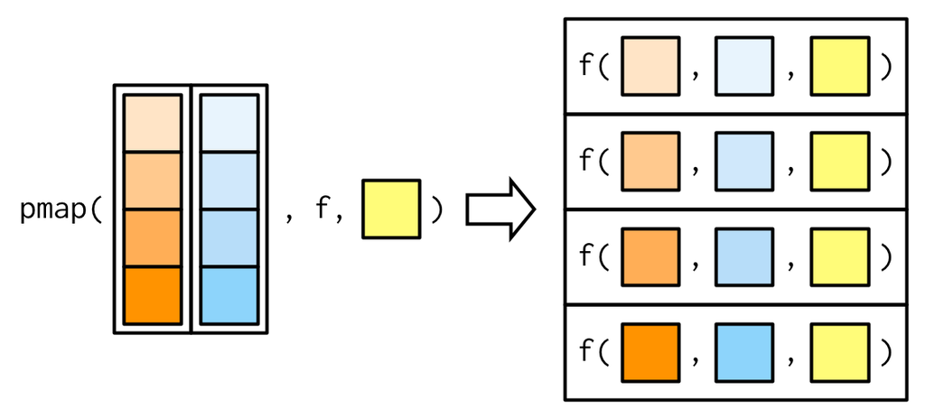

> A big difference between `pmap()` and the other map functions is that *`pmap()` gives you much finer control over argument matching because you can name the components of the list.*

```r
draws <- rcauchy(1000)
trims <- c(0, 0.1, 0.2, 0.5)

identical(
  map_dbl(trims, function(input) mean(x = draws, trim = input)),
  pmap_dbl(list(trim = trims), mean, x = draws)
  )
```

```
[1] TRUE
```

Note that name matching makes `pmap()` very easy to work with data frames.

For example:

```r
params <- data.frame(       ## Here, the column names
  n = c(1, 3, 5),           ## are critical!
  mean = c(0, 10, 1000),
  sd = c(1, 10, 100)
)

params
```

```
  n mean  sd
1 1    0   1
2 3   10  10
3 5 1000 100
```

```r
pmap(params, rnorm)
```

```
[[1]]
[1] 0.4963721

[[2]]
[1]  1.921157 11.854122  1.255596

[[3]]
[1] 1067.9043  989.9370 1050.3264  952.6846  954.2928
```

*Exercises*

> Rewrite the following code to use `iwalk()` instead of `walk2()`. What are the advantages and disadvantages?

```r
temp <- tempfile()
dir.create(temp)

cyls <- split(mtcars, mtcars$cyl)
paths <- file.path(temp, paste0("cyl-", names(cyls), ".csv"))

## Original
walk2(cyls, paths, write.csv)
list.files(temp)
```

```
[1] "cyl-4.csv" "cyl-6.csv" "cyl-8.csv"
```

```r
## Solution
names(cyls) <- paths      ## Disadvantage: names are overwritten
iwalk(cyls, ~ write.csv)  ## Advantage: code is slightly shorter
list.files(temp)
```

```
[1] "cyl-4.csv" "cyl-6.csv" "cyl-8.csv"
```

### Reduce and Accumulate

> After the map family, the next most important family of functions is the reduce family. This family is much smaller, with only two main variants, and is used less commonly, but it’s a powerful idea, gives us the opportunity to discuss some useful algebra, and powers the map-reduce framework frequently used for processing very large datasets.

> [`reduce()`](https://purrr.tidyverse.org/reference/reduce.html) takes a vector of length `n` and produces a vector of length `1` by calling a function with a pair of values at a time: `reduce(1:4, f)` is equivalent to `f(f(f(1, 2), 3), 4)`.

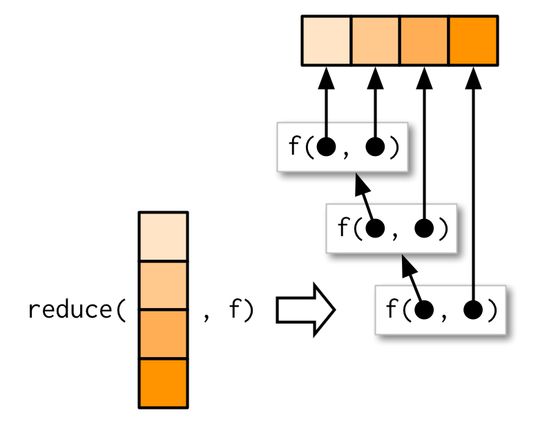

```r
fruit_lists <- map(1:4, ~sample(fruit, 35))

## This...
fruit_lists[[1]] %>%
  intersect(fruit_lists[[2]]) %>%
  intersect(fruit_lists[[3]]) %>%
  intersect(fruit_lists[[4]])
```

```
[1] "cloudberry" "papaya"
```

```r
## ...is equivalent to this
reduce(fruit_lists, intersect)
```

```
[1] "cloudberry" "papaya"
```

`accumulate()` is a variant of `reduce()` that returns all the intermediate results as well.

```r
accumulate(fruit_lists, intersect)
```

```
[[1]]
 [1] "physalis"     "gooseberry"   "lychee"       "cranberry"
 [5] "breadfruit"   "ugli fruit"   "mandarine"    "plum"
 [9] "elderberry"   "rock melon"   "cloudberry"   "rambutan"
[13] "jujube"       "banana"       "raspberry"    "boysenberry"
[17] "nectarine"    "nut"          "olive"        "kiwi fruit"
[21] "guava"        "chili pepper" "lime"         "clementine"
[25] "watermelon"   "salal berry"  "strawberry"   "currant"
[29] "coconut"      "satsuma"      "kumquat"      "pamelo"
[33] "papaya"       "grapefruit"   "jambul"

[[2]]
 [1] "physalis"   "gooseberry" "lychee"     "cranberry"  "cloudberry"
 [6] "banana"     "nectarine"  "guava"      "clementine" "watermelon"
[11] "currant"    "satsuma"    "papaya"     "grapefruit" "jambul"

[[3]]
[1] "cloudberry" "banana"     "nectarine"  "satsuma"    "papaya"
[6] "grapefruit"

[[4]]
[1] "cloudberry" "papaya"
```

**Note.** These two functions behave a lot like `sum()` and `cumsum()`.

```r
x <- c(4, 3, 10, 12)
reduce(x, `+`) ## sum()
```

```
[1] 29
```

```r
accumulate(x, `+`) ## cumsum()
```

```
[1]  4  7 17 29
```

Finally, the `.init` argument allows you to supply an initial element to these functions.

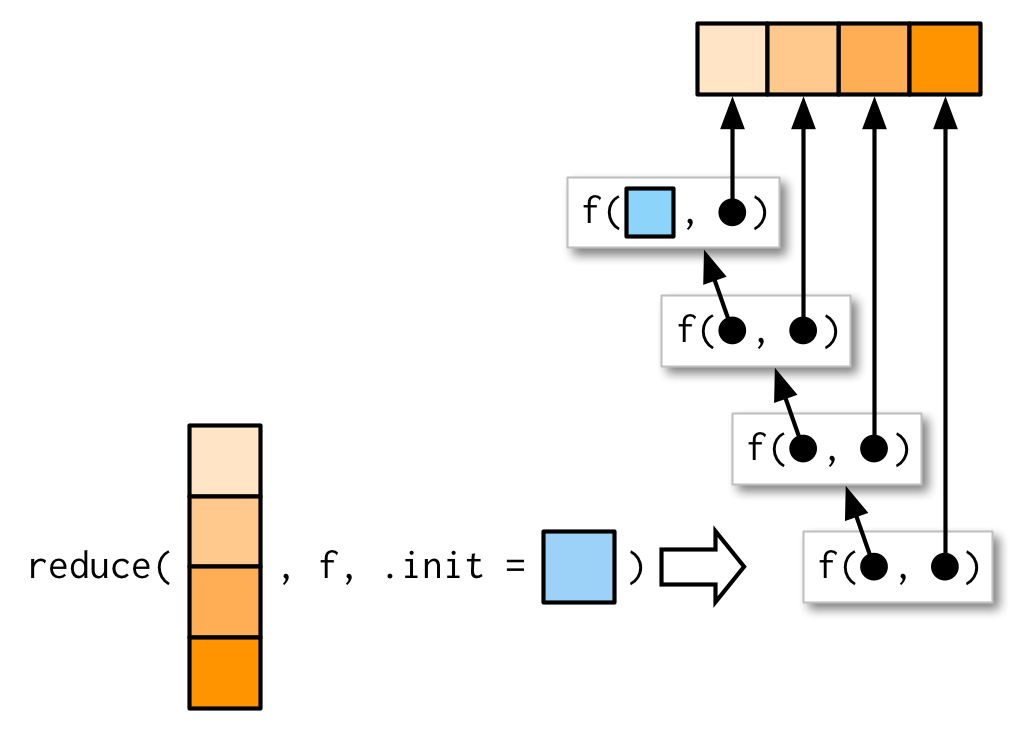

> So if we call `` reduce(1, `+`, init) `` the result will be `1 + init`.

```r
reduce(1:2, `+`, .init = 1)
```

```
[1] 4
```

This argument can become important if you are not sure what you’re input might look like, and you want to avoid an error. In mathematics, we refer to the `.init` argument as the [identity element](https://en.wikipedia.org/wiki/Identity_element): “a special type of element of a set with respect to a binary operation on that set, which leaves any element of the set unchanged when combined with it.”

```r
sum(integer())
```

```
[1] 0
```

```r
prod(integer())
```

```
[1] 1
```

> If you’re using `reduce()` in a function, you should always supply `.init`. Think carefully about what your function should return when you pass a vector of length `0` or `1`, and make sure to test your implementation.

*Map-reduce*

> You might have heard of map-reduce, the idea that powers technology like Hadoop. Now you can see how simple and powerful the underlying idea is: map-reduce is a map combined with a reduce. The difference for large data is that the data is spread over multiple computers. Each computer performs the map on the data that it has, then it sends the result to back to a coordinator which reduces the individual results back to a single result.

> As a simple example, imagine computing the mean of a very large vector, so large that it has to be split over multiple computers. You could ask each computer to calculate the sum and the length, and then return those to the coordinator which computes the overall mean by dividing the total sum by the total length.

### Predicates

> A **predicate** is a function that returns a single `TRUE` or `FALSE`, like `is.character()`, `is.null()`, or `all()`, and we say a predicate *matches* a vector if it returns `TRUE.`

The `purrr` package has three pairs of useful functions that apply a predicate to each element in a vector.

1. *`some(.x, .p)` returns TRUE if any element matches; `every(.x, .p)` returns TRUE if all elements match.*

   *These are equivalent to `any(map_lgl(.x, .p))` and `all(map_lgl(.x, .p))`, except that they terminate early: `some()` returns `TRUE` when it sees the first `TRUE`, and `every()` returns `FALSE` when it sees the first `FALSE.`*
2. *`detect(.x, .p)` returns the* value *of the first match; `detect_index(.x, .p)` returns the* location *of the first match.*
3. *`keep(.x, .p)`* keeps *all matching elements; `discard(.x, .p)`* drops *all matching elements.*

```r
df <- data.frame(
  x = 1:3,
  y = c("a", "b", "c")  ## stringsAsFactors = TRUE by default
  )

every(df, is.factor)
```

```
[1] FALSE
```

```r
some(df, is.factor)
```

```
[1] TRUE
```

```r
detect(df, is.integer)
```

```
[1] 1 2 3
```

```r
detect_index(df, is.factor)
```

```
[1] 2
```

```r
keep(df, is.factor) %>% str()
```

```
'data.frame':   3 obs. of  1 variable:
 $ y: Factor w/ 3 levels "a","b","c": 1 2 3
```

```r
discard(df, is.factor) %>% str()
```

```
'data.frame':   3 obs. of  1 variable:
 $ x: int  1 2 3
```

Note the following:

> `map()` and `modify()` come in variants that also take predicate functions, transforming only the elements of `.x` where `.p` is `TRUE`.

```r
map_if(df, is.numeric, mean) %>% str()
```

```
List of 2
 $ x: num 2
 $ y: Factor w/ 3 levels "a","b","c": 1 2 3
```

```r
modify_if(df, is.numeric, max) %>% str()
```

```
'data.frame':   3 obs. of  2 variables:
 $ x: int  3 3 3
 $ y: Factor w/ 3 levels "a","b","c": 1 2 3
```

```r
## this will drop the factor, and avoid recycling
keep(df, is.numeric) %>% map(mean) %>% str()
```

```
List of 1
 $ x: num 2
```

*Exercises*

> Implement the `span()` function from Haskell: given a list `x` and a predicate function `f`, `span(x, f)` returns the location of the longest sequential run of elements where the predicate is true. (Hint: you might find `rle()` helpful.)

```r
span <- function(x, f) {
  ## this makes "values" and "lengths" available
  list2env(rle(map_lgl(x, f)), envir = rlang::caller_env())
  if (!any(values)) {
    return(integer())
  }
  index <- which(lengths == max(lengths[values]))[[1]] ## lgl sub
  first <- cumsum(lengths)[index] - (lengths[index] - 1)
  return(first:(first + lengths[index] - 1))
}

span(iris, is.factor)
```

```
[1] 5
```

```r
span(iris, is.numeric)
```

```
[1] 1 2 3 4
```

```r
arg_max <- function(x, f) {
  output <- map_dbl(x, f)
  x[output == max(output)] ## lgl subsetting
}

arg_min <- function(x, f) {
  output <- map_dbl(x, f)
  x[output == min(output)] ## lgl subsetting
}
```

### Extra

**Math**

> Functionals are very common in mathematics. The limit, the maximum, the roots (the set of points where $f(x) = 0$), and the definite integral are all functionals: given a function, they return a single number (or vector of numbers). At first glance, these functions don’t seem to fit in with the theme of eliminating loops, but if you dig deeper you’ll find out that they are all implemented using an algorithm that involves iteration.
- `integrate()` finds the area under the curve defined by `f()`
- `uniroot()` finds where `f()` hits zero
- `optimise()` finds the location of the lowest (or highest) value of `f()`

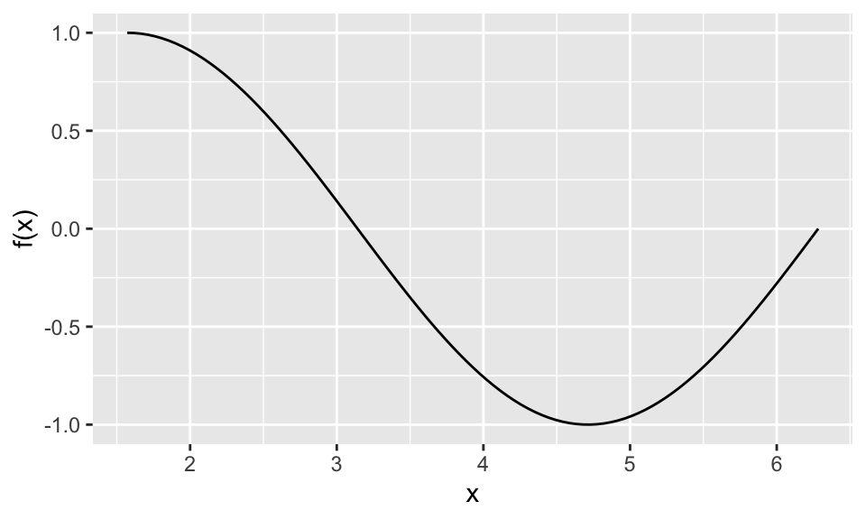

```r
integrate(sin, lower = 2/pi, upper = 2*pi)
```

```
-0.1958902 with absolute error < 4.2e-14
```

```r
uniroot(sin, lower = 2/pi, upper = 2*pi)
```

```
$root
[1] 3.141592

$f.root
[1] 2.869081e-07

$iter
[1] 7

$init.it
[1] NA

$estim.prec
[1] 6.103516e-05
```

```r
optimise(sin, lower = 2/pi, upper = 2*pi)
```

```
$minimum
[1] 4.71239

$objective
[1] -1
```

```r
optimise(sin, lower = 2/pi, upper = 2*pi, maximum = TRUE)
```

```
$maximum
[1] 1.570811

$objective
[1] 1
```

**Matrices and arrays**

The `map()` family of functions is designed to work with one-dimensional vectors. If we wish to work with n-dimensional vectors, we use `base::apply()`. It has four arguments:

- `X`, *the matrix or array to summarise.*
- `MARGIN`, *an integer vector giving the dimensions to summarise over, 1 = rows, 2 = columns, etc. (The argument name comes from thinking about the margins of a joint distribution.)*
- `FUN`, *a summary function.*
- `...` *other arguments passed on to `FUN`.*

```r
A <- array(1:24, dim = c(4, 3, 2))
A
```

```
, , 1

     [,1] [,2] [,3]
[1,]    1    5    9
[2,]    2    6   10
[3,]    3    7   11
[4,]    4    8   12

, , 2

     [,1] [,2] [,3]
[1,]   13   17   21
[2,]   14   18   22
[3,]   15   19   23
[4,]   16   20   24
```

```r
apply(A, MARGIN = 1, mean)
```

```
[1] 11 12 13 14
```

```r
apply(A, MARGIN = 2, mean)
```

```
[1]  8.5 12.5 16.5
```

```r
apply(A, MARGIN = 3, mean)
```

```
[1]  6.5 18.5
```

*Exercises*

> Challenge: read about the [fixed point algorithm](https://mitpress.mit.edu/sites/default/files/sicp/full-text/book/book-Z-H-12.html#%25_idx_1096). Complete the exercises using R.

A number $x$ is called a fixed point of a function $f$ if it satisfies the following equation:

$$f(x) = x$$

We can come up with a procedure that locates fixed-points by begining with an initial guess and aplying $f$ repeatedly until the value doesn’t change much.

```r
fixed_point <- function(f, init, tolerance = 0.00001) {
  if (abs(f(init) - init) <= tolerance) {
    return(c("fixed point" = init))
  } else {
    fixed_point(f, f(init))    ## using recursion
  }
}

fixed_point(cos, init = 5)
```

```
fixed point
  0.7390798
```

We can find an approximate solution to the equation $x = \cos x + \sin x$ using this method.

```r
fixed_point(function(x) cos(x) + sin(x), 1)
```

```
fixed point
   1.258723
```

We can find the golden ratio $\phi$, which satisfies the equation $\phi = 1 + \frac{1}{\phi}$.

```r
fixed_point(function(x) 1 + 1/x, 1)
```

```
fixed point
   1.618037
```

## Function Factories

```r
library(rlang)
```

Function factories are functions that create functions.

For example:

```r
power <- function(exp) {
  function(x) {
    x ^ exp
  }
}

square <- power(2)
square(4)
```

```
[1] 16
```

```r
cube <- power(3)
cube(4)
```

```
[1] 64
```

R has three features that, combined with each other, lead to the possibility of function factories:

1. In R, you bind a function to a name in the same way as you bind any object to a name: with the assignment operator `<-`.
2. In R, functions capture (or enclose) the environments in which they’re created, that’s why they’re sometimes called *closures*.
3. In R, a function creates a new execution environment every time it is run. This environment is usually temporary, but here it becomes the enclosing environment of the “manufactured function”.

The key idea is as follows:

> The enclosing environment of the manufactured function is an execution environment of the function factory.